# Case Study: How does a bike-share navigate speedy success?

## Background

Cyclistic, a Chicago-based bike-share company, would like to design a new marketing campaign to boost the number of annual subscription. The most probable way to achieve this goal is to attract casual riders using Cyclistic’s bikes to join the membership. Therefore, we want to explore the differences between casual riders and Cyclistic members through data to figure out which types of casual riders are the most efficient to marketing to. The insight will be used by the Cyclistic marketing analytics team to design marketing strategy.

## Import libraries

```r
library(tidyverse)
library(dplyr)
library(lubridate)
library(ggplot2)
```

## Import dataset

Data source: https://divvy-tripdata.s3.amazonaws.com/index.html

We will be using data from Nov-2021 to Oct-2022 for analysis.

```r
df <- list.files(path = "/Users/boscowong0125/Desktop/Coursera Google Data Analytics/Course 8/Case study 1/Data",  # Identify all CSV files
                       pattern = "*.csv", full.names = TRUE) %>%
  lapply(read_csv) %>%                              # Store all files in list
  bind_rows                                         # Combine data sets into one data set

head(df)
```

```
## # A tibble: 6 × 13
##   ride_id        ridea…¹ started_at          ended_at            start…² start…³
##   <chr>          <chr>   <dttm>              <dttm>              <chr>   <chr>
## 1 7C00A93E10556… electr… 2021-11-27 13:27:38 2021-11-27 13:46:38 <NA>    <NA>
## 2 90854840DFD50… electr… 2021-11-27 13:38:25 2021-11-27 13:56:10 <NA>    <NA>
## 3 0A7D10CDD1440… electr… 2021-11-26 22:03:34 2021-11-26 22:05:56 <NA>    <NA>
## 4 2F3BE33085BCF… electr… 2021-11-27 09:56:49 2021-11-27 10:01:50 <NA>    <NA>
## 5 D67B4781A1992… electr… 2021-11-26 19:09:28 2021-11-26 19:30:41 <NA>    <NA>
## 6 02F85C2C3C5F7… electr… 2021-11-26 18:34:07 2021-11-26 18:52:49 Michig… 13042
## # … with 7 more variables: end_station_name <chr>, end_station_id <chr>,
## #   start_lat <dbl>, start_lng <dbl>, end_lat <dbl>, end_lng <dbl>,
## #   member_casual <chr>, and abbreviated variable names ¹rideable_type,
## #   ²start_station_name, ³start_station_id
```

## Data cleaning

```r
# number of rows and columns
dim(df)
```

```
## [1] 5755694      13
```

```r
# column names
colnames(df)
```

```
##  [1] "ride_id"            "rideable_type"      "started_at"
##  [4] "ended_at"           "start_station_name" "start_station_id"
##  [7] "end_station_name"   "end_station_id"     "start_lat"
## [10] "start_lng"          "end_lat"            "end_lng"
## [13] "member_casual"
```

```r
# data structure
str(df)
```

```
## spc_tbl_ [5,755,694 × 13] (S3: spec_tbl_df/tbl_df/tbl/data.frame)
##  $ ride_id           : chr [1:5755694] "7C00A93E10556E47" "90854840DFD508BA" "0A7D10CDD144061C" "2F3BE33085BCFF02" ...
##  $ rideable_type     : chr [1:5755694] "electric_bike" "electric_bike" "electric_bike" "electric_bike" ...
##  $ started_at        : POSIXct[1:5755694], format: "2021-11-27 13:27:38" "2021-11-27 13:38:25" ...
##  $ ended_at          : POSIXct[1:5755694], format: "2021-11-27 13:46:38" "2021-11-27 13:56:10" ...
##  $ start_station_name: chr [1:5755694] NA NA NA NA ...
##  $ start_station_id  : chr [1:5755694] NA NA NA NA ...
##  $ end_station_name  : chr [1:5755694] NA NA NA NA ...
##  $ end_station_id    : chr [1:5755694] NA NA NA NA ...
##  $ start_lat         : num [1:5755694] 41.9 42 42 41.9 41.9 ...
##  $ start_lng         : num [1:5755694] -87.7 -87.7 -87.7 -87.8 -87.6 ...
##  $ end_lat           : num [1:5755694] 42 41.9 42 41.9 41.9 ...
##  $ end_lng           : num [1:5755694] -87.7 -87.7 -87.7 -87.8 -87.6 ...
##  $ member_casual     : chr [1:5755694] "casual" "casual" "casual" "casual" ...
##  - attr(*, "spec")=
##   .. cols(
##   ..   ride_id = col_character(),
##   ..   rideable_type = col_character(),
##   ..   started_at = col_datetime(format = ""),
##   ..   ended_at = col_datetime(format = ""),
##   ..   start_station_name = col_character(),
##   ..   start_station_id = col_character(),
##   ..   end_station_name = col_character(),
##   ..   end_station_id = col_character(),
##   ..   start_lat = col_double(),
##   ..   start_lng = col_double(),
##   ..   end_lat = col_double(),
##   ..   end_lng = col_double(),
##   ..   member_casual = col_character()
##   .. )
##  - attr(*, "problems")=<externalptr>
```

```r
# descriptive statistics
summary(df)
```

```
##    ride_id          rideable_type        started_at
##  Length:5755694     Length:5755694     Min.   :2021-11-01 00:00:14
##  Class :character   Class :character   1st Qu.:2022-04-27 16:40:09
##  Mode  :character   Mode  :character   Median :2022-06-30 18:31:03
##                                        Mean   :2022-06-13 23:04:32
##                                        3rd Qu.:2022-08-24 19:52:19
##                                        Max.   :2022-10-31 23:59:33
##
##     ended_at                   start_station_name start_station_id
##  Min.   :2021-11-01 00:04:06   Length:5755694     Length:5755694
##  1st Qu.:2022-04-27 16:51:40   Class :character   Class :character
##  Median :2022-06-30 18:49:28   Mode  :character   Mode  :character
##  Mean   :2022-06-13 23:23:58
##  3rd Qu.:2022-08-24 20:10:05
##  Max.   :2022-11-07 04:53:58
##
##  end_station_name   end_station_id       start_lat       start_lng
##  Length:5755694     Length:5755694     Min.   :41.64   Min.   :-87.84
##  Class :character   Class :character   1st Qu.:41.88   1st Qu.:-87.66
##  Mode  :character   Mode  :character   Median :41.90   Median :-87.64
##                                        Mean   :41.90   Mean   :-87.65
##                                        3rd Qu.:41.93   3rd Qu.:-87.63
##                                        Max.   :45.64   Max.   :-73.80
##
##     end_lat         end_lng       member_casual
##  Min.   :41.39   Min.   :-88.97   Length:5755694
##  1st Qu.:41.88   1st Qu.:-87.66   Class :character
##  Median :41.90   Median :-87.64   Mode  :character
##  Mean   :41.90   Mean   :-87.65
##  3rd Qu.:41.93   3rd Qu.:-87.63
##  Max.   :42.37   Max.   :-87.30
##  NA's   :5835    NA's   :5835
```

There are 5755694 observations and 13 columns in the dataset. “ride_id” is the primary key for this dataframe.

Next, we want to add new columns to the dataframe to facilitate subsequent analysis. We will add a new column “ride_duration” to represent the length of ride. Also, “started_at” will be break down into “ride_year”, “ride_month”, “ride_day” and “ride_day_of_week” columns.

```r
df$ride_duration <- df$ended_at - df$started_at
df$ride_duration <- as.numeric(as.character(df$ride_duration))
df$ride_day <- format(as.Date(df$started_at), "%d")
df$ride_month <- format(as.Date(df$started_at), "%m")
df$ride_year <- format(as.Date(df$started_at), "%Y")
df$ride_day_of_week <- format(as.Date(df$started_at), "%A")
```

We want to remove unnecessary columns and non-sense rows as well.

For columns, we will remove “start_lat”, “start_lng”, “end_lat”, “end_lng”, “start_station_id” and “end_station_id” as they are no longer useful for our analysis.

```r
# remove columns
df <- df %>%
  select(-c(start_lat, start_lng, end_lat, end_lng, start_station_id, end_station_id))
# remove rows with non-positive ride_duration
df <- df[!(df$ride_duration < 0), ]
# remove missing value with no member or casual label
df <- df[(df$member_casual == "member" | df$member_casual == "casual"), ]
str(df)
```

```
## tibble [5,755,582 × 12] (S3: tbl_df/tbl/data.frame)
##  $ ride_id           : chr [1:5755582] "7C00A93E10556E47" "90854840DFD508BA" "0A7D10CDD144061C" "2F3BE33085BCFF02" ...
##  $ rideable_type     : chr [1:5755582] "electric_bike" "electric_bike" "electric_bike" "electric_bike" ...
##  $ started_at        : POSIXct[1:5755582], format: "2021-11-27 13:27:38" "2021-11-27 13:38:25" ...
##  $ ended_at          : POSIXct[1:5755582], format: "2021-11-27 13:46:38" "2021-11-27 13:56:10" ...
##  $ start_station_name: chr [1:5755582] NA NA NA NA ...
##  $ end_station_name  : chr [1:5755582] NA NA NA NA ...
##  $ member_casual     : chr [1:5755582] "casual" "casual" "casual" "casual" ...
##  $ ride_duration     : num [1:5755582] 1140 1065 142 301 1273 ...
##  $ ride_day          : chr [1:5755582] "27" "27" "26" "27" ...
##  $ ride_month        : chr [1:5755582] "11" "11" "11" "11" ...
##  $ ride_year         : chr [1:5755582] "2021" "2021" "2021" "2021" ...
##  $ ride_day_of_week  : chr [1:5755582] "Saturday" "Saturday" "Friday" "Saturday" ...
```

Now, the dataframe is ready for analysis

## Exploratory Data Analysis

We will first look into the “ride_duration” as it should be the most intuitive to decide whether the riders are members or not.

```r
# descriptive analysis
summary(df$ride_duration)
```

```
##    Min. 1st Qu.  Median    Mean 3rd Qu.    Max.
##       0     351     620    1167    1114 2483235
```

```r
# members verses casual riders
aggregate(df$ride_duration ~ df$member_casual, FUN = mean)
```

```
##   df$member_casual df$ride_duration
## 1           casual        1750.3054
## 2           member         762.8815
```

```r
aggregate(df$ride_duration ~ df$member_casual, FUN = median)
```

```
##   df$member_casual df$ride_duration
## 1           casual              790
## 2           member              530
```

```r
aggregate(df$ride_duration ~ df$member_casual, FUN = max)
```

```
##   df$member_casual df$ride_duration
## 1           casual          2483235
## 2           member            93594
```

```r
aggregate(df$ride_duration ~ df$member_casual, FUN = min)
```

```
##   df$member_casual df$ride_duration
## 1           casual                0
## 2           member                0
```

The average ride time by each day for member vs casual riders:

```r
df$ride_day_of_week <- ordered(df$ride_day_of_week, levels=c("Sunday", "Monday", "Tuesday", "Wednesday", "Thursday", "Friday", "Saturday"))
aggregate(df$ride_duration ~ df$member_casual + df$ride_day_of_week, FUN = mean)
```

```
##    df$member_casual df$ride_day_of_week df$ride_duration
## 1            casual              Sunday        2031.1183
## 2            member              Sunday         844.7337
## 3            casual              Monday        1757.6043
## 4            member              Monday         737.7097
## 5            casual             Tuesday        1561.1835
## 6            member             Tuesday         728.1012
## 7            casual           Wednesday        1494.3808
## 8            member           Wednesday         724.7810
## 9            casual            Thursday        1528.2472
## 10           member            Thursday         734.8682
## 11           casual              Friday        1674.3550
## 12           member              Friday         748.6522
## 13           casual            Saturday        1958.0404
## 14           member            Saturday         850.9703
```

## Visualization

### The number of rides by type (member_casual) and weekday:

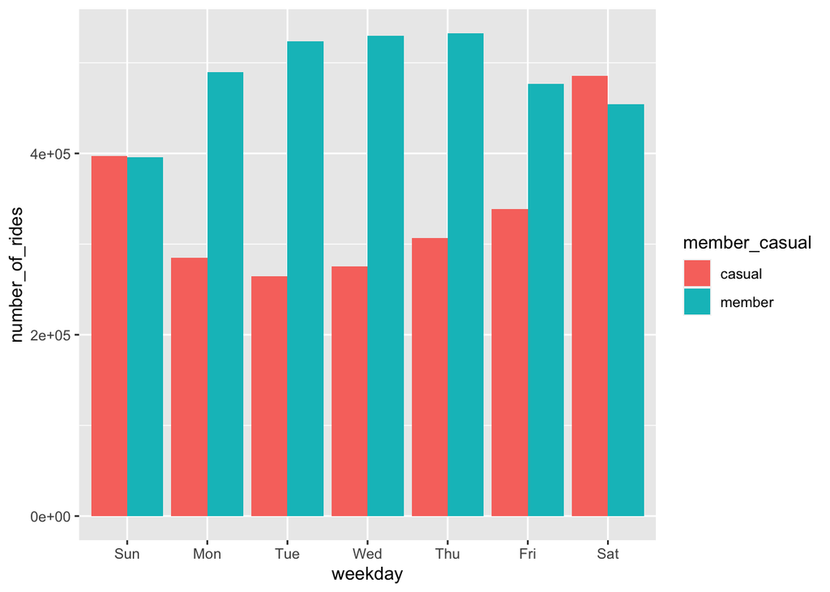

```r
df %>%
  mutate(weekday = wday(started_at, label=TRUE)) %>%
  group_by(member_casual, weekday) %>%
  summarise(number_of_rides = n(), average_duration = mean(ride_duration)) %>%
  arrange(member_casual, weekday) %>%
  ggplot(aes(x = weekday, y = number_of_rides, fill = member_casual)) + geom_col(position = "dodge")
```

Observation:

1. Casual riders use Cyclistic bikes on weekends more than on weekdays.
2. Cyclistic members use Cyclistic bikes on weekdays more than on weekends.
3. On weekdays, Cyclistic members take more rides than casual riders.
4. On weekends, the number of rides taken by Cyclistic members and casual riders are roughly the same.

### The average length of rides by type (member_casual) and weekday:

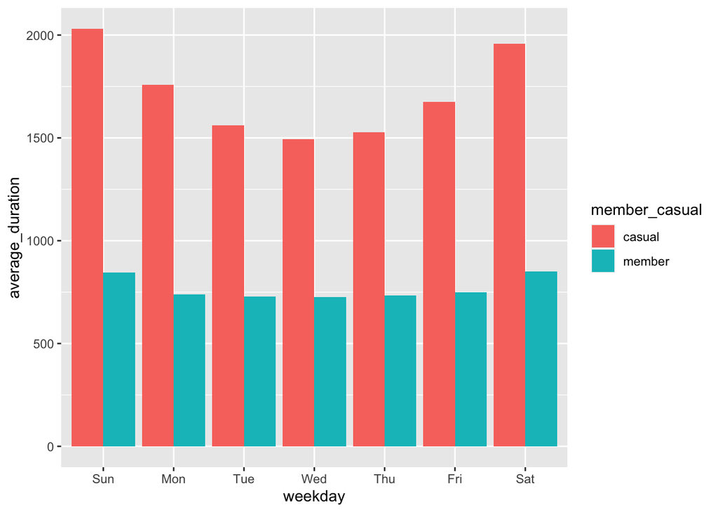

```r
df %>%
  mutate(weekday = wday(started_at, label=TRUE)) %>%
  group_by(member_casual, weekday) %>%
  summarise(number_of_rides = n(), average_duration = mean(ride_duration)) %>%
  arrange(member_casual, weekday) %>%
  ggplot(aes(x = weekday, y = average_duration, fill = member_casual)) + geom_col(position = "dodge")
```

Observation: